# CS233 Homework 1 (total points: 100)

- Run all code cells so that every block shows its output before exporting.
- Export as HTML (.html) and submit that file.
- To get all points for each question, you need to include the output of your code AND your explanation.

## Question 1 (output 5 points, explanation 5 points, 10 points in total):

Create a 1D NumPy array containing the integers from 0 to 9 (inclusive). Print the array and its `dtype`.

```python
import numpy as np

numbers = np.array(range(10))

print(numbers, numbers.dtype)
```

```
[0 1 2 3 4 5 6 7 8 9] int64
```

Your explanation: First we assign the variable numbers using numpy's array class and give it a range of 10 as to include the numbers between 0 and 9.

This array is a one dimensional (flat) array given that we have no second row.

Numpy by default will try to assign a default dtype which in this case are 64 bit integers.

Finally we print both the array itself and its dtype by calling it's ndarray object property.

## Question 2 (output 5 points, explanation 5 points, 10 points in total):

Given a 1D array `a = np.array([3, 6, 9, 12, 15])`, compute (a) the elementwise square of `a` and (b) the sum of all elements. Show both results. Noted that you must sove the problem of using array-oriented programming (no for loop allowed).

```python
import numpy as np

a = np.array([3, 6, 9, 12, 15])
squared = np.square(a)
total = np.sum(a)

print(f"squared : {squared}\nsum : {total}")
```

```
squared : [  9  36  81 144 225]
sum : 45
```

Your explanation:

We define two variables `squared` and `total` then using numpy functions `numpy.square` and `numpy.sum()` we find the elementwise square of a and the sum of a.

The output is using an f-string to print both variables.

## Question 3 (output 5 points, explanation 5 points, 10 points in total):

Construct a 2x3 array filled with zeros and then replace the last column with ones using slicing (without loops). Display the final array.

```python
import numpy as np

matrix = np.zeros((2, 3))

matrix[: , -1:] = 1

print(matrix)
```

```
[[0. 0. 1.]
 [0. 0. 1.]]
```

Your explanation:

We first specify that we want to modify every row of the matrix by using `:`, then we use `-1:` to indicate that we want to modify the last element of each row. We then assign that value as 1. Something to note is that this solution allows the matrix to be any size.

## Question 4 (output 5 points, explanation 5 points, 10 points in total):

Let `b = np.arange(12).reshape(3, 4)`.

1. Extract the second row of b.
2. Extract the fourth column of b.
3. Compute the mean of all elements in b.

```python
import numpy as np

b = np.arange(12).reshape(3, 4)

print(b) #for refrence

# second row
row2 = b[1]

# fourth column
col4 = b[:, 3:]

# mean of all elements
mean_val = b.mean()

print("Second row:", row2)
print("Fourth column:", col4)
print("Mean of all elements:", mean_val)
```

```
[[ 0  1  2  3]
 [ 4  5  6  7]
 [ 8  9 10 11]]
Second row: [4 5 6 7]
Fourth column: [[ 3]
 [ 7]
 [11]]
Mean of all elements: 5.5
```

Your explanation:

Selecting row 2 uses a slice value of 1 because python counts with a zero index meaning that our first element `[0, 1, 2, 3]` in python's eyes is zero and our second element `[4, 5, 6, 7]` is refrenced as the first. This is like the difference between the first floor in the US versus Europe we call the ground floor the first floor while Europeans would call it zero (or just ground floor).

As for getting the fourth column similar methods seen in question 3 are used. An important distinction is that we are not selecting only the last element like done previously as if the shape of b was differnt the value of the last column and fourth column would not always be the same value.

A nparray instance has a built in function to calculate the mean of the array.

## Question 5 (output 5 points, explanation 5 points, 10 points in total):

Given a 4x4 array of consecutive integers starting at 10. Use boolean masking to set all elements greater than 20 to zero and print the modified array.

```python
import numpy as np

array_4_4 = np.arange(10, 26).reshape(4, 4)

print(array_4_4)

array_4_4[array_4_4 > 20] = 0

print(array_4_4)
```

```
[[10 11 12 13]
 [14 15 16 17]
 [18 19 20 21]
 [22 23 24 25]]
[[10 11 12 13]
 [14 15 16 17]
 [18 19 20  0]
 [ 0  0  0  0]]
```

Your explanation:

We make a call to access the array with the use of the `[ ]` the argument we pass a boolean mask for an argument `array_4_4 > 20` and assign anywhere the results to `True` to zero.

## Question 6 (output 5 points, explanation 5 points, 10 points in total):

You are given a 2D NumPy.

1.Compute the cumulative sum down the columns. Show the output and explain how the numbers are calculated column by column.

2.Compute the cumulative sum across each row. Show the output and explain how the numbers are calculated row by row.

```python
import numpy as np

arr = np.array([[0, 1, 2],
                [3, 4, 5],
                [6, 7, 8]])

print("Cumulative sum down columns:")
x = arr.cumsum(axis = 0)
print(x)

print("\nCumulative sum across rows:")
y = arr.cumsum(axis = 1)
print(y)
```

```
Cumulative sum down columns:
[[ 0  1  2]
 [ 3  5  7]
 [ 9 12 15]]

Cumulative sum across rows:
[[ 0  1  3]
 [ 3  7 12]
 [ 6 13 21]]
```

Your explanation:

We assign the variables x and y with respective array function calls to the `nparray.cumsum()` function. This function returns the cumulative sum of elements along a given axis which we pass the argument `axis = 0` and `axis = 1`to take the sum across column and rows respectively.

## Question 7 (output 5 points, explanation 5 points, 10 points in total):

You are given a 5×5 array of random integers between -5 and 5.

1. Replace even numbers with 1 and odd numbers with -1.
2. Show the final array.

```python
import numpy as np

# Create array of random integers from -5 to 5
rng = np.random.default_rng(seed=42)
arr = rng.integers(-5, 6, size=(5, 5))
print("Original array:")
print(arr)

# hint 1: First find even numbers (boolean mask)
#arr[arr % 2 == 0] = 1
# hint 2: Replace even numbers with 1, odd numbers with -1, by using np.where
new_arr = np.where(arr % 2 == 0, 1, -1)
print("Transformed array:")
print(new_arr)
```

```
Original array:
[[-5  3  2 -1 -1]
 [ 4 -5  2 -3 -4]
 [ 0  5  3  3  2]
 [ 3  0 -4  4 -1]
 [ 0 -1 -3  5  3]]
Transformed array:
[[-1 -1  1 -1 -1]
 [ 1 -1  1 -1  1]
 [ 1 -1 -1 -1  1]
 [-1  1  1  1 -1]
 [ 1 -1 -1 -1 -1]]
```

Your explanation:

First the commented out line `arr[arr % 2 == 0] = 1` was to understand boolean masking. Then that is applied in an arugment inside of `np.where` to our `new_arr`'s data with 1, or -1 based on the result of `arr`'s data value mod (`%`) 2. If that result is zero thne we assign 1 (which all even numbers will) otherwise -1.

## Question 8 (output 5 points, explanation 5 points, 10 points in total):

Create a 2D NumPy array (4×5) with random numbers generated from a standard normal distribution, then sort it along columns and rows separately.

```python
import numpy as np

rng = np.random.default_rng(seed=45)

arr = rng.standard_normal(size=(4,5))

print(f"Default array:\n{arr}\n")
print(f"Sorted by column:\n{np.sort(arr, axis=0)}\n")
print(f" Sorted by row:\n {np.sort(arr, axis=1)}")

# Your code
# print the array sorted by columns
# print the array sorted by rows
```

```
Default array:
[[-0.45786521 -0.62285868  0.13529003  0.84390259 -0.14849869]
 [ 0.26248378  0.53166804  0.6898073  -0.89189867  0.46882042]
 [-0.01778763 -0.6014297  -0.67763502 -0.22721533 -0.9935554 ]
 [-1.45890289  0.06375738  0.77451782 -0.24113171  0.7400469 ]]

Sorted by column:
[[-1.45890289 -0.62285868 -0.67763502 -0.89189867 -0.9935554 ]
 [-0.45786521 -0.6014297   0.13529003 -0.24113171 -0.14849869]
 [-0.01778763  0.06375738  0.6898073  -0.22721533  0.46882042]
 [ 0.26248378  0.53166804  0.77451782  0.84390259  0.7400469 ]]

 Sorted by row:
 [[-0.62285868 -0.45786521 -0.14849869  0.13529003  0.84390259]
 [-0.89189867  0.26248378  0.46882042  0.53166804  0.6898073 ]
 [-0.9935554  -0.67763502 -0.6014297  -0.22721533 -0.01778763]
 [-1.45890289 -0.24113171  0.06375738  0.7400469   0.77451782]]
```

## Question 9 (20 points in total)

Hint: Read Chapter 4.7 (https://wesmckinney.com/book/numpy-basics#example_random_walks) and understand the random walk problem and complete the following question

a) (5 points) Pure Python Way: Simulate one random walk of 800 steps where each step is either +2 or -2 with equal probability. Plot the walk by using the provided code.

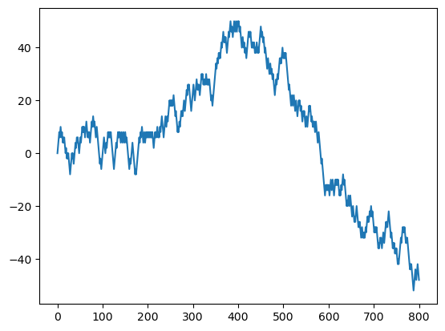

```python
import numpy as np
import matplotlib.pyplot as plt # pip install matplotlib, if you don't have it installed
import random
random.seed(45)
position = 0
walk = [position]
for i in range(800):
    step = 2 if random.randint(0, 1) else -2
    position += step
    walk.append(position)

plt.plot(walk[:])
```

b) (5 points) Numpy Way: Solve question a) using numpy way, so for-loop is not allowed.

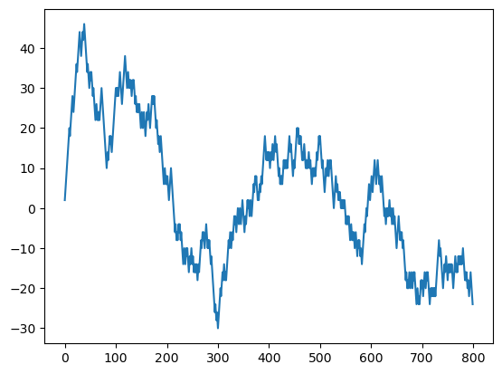

```python
rng = np.random.default_rng(seed=45)
draws = rng.integers(0, 2, size=800)
steps = np.where(draws == 1, 2, -2)
walk = steps.cumsum()
plt.plot(walk[:])
```

c) (10 points = 6 points coding + 4 points explanation) use numpy coding style

Simulate one walk 1000 steps each with two different setups:

- Steps of ±1 (equal probability).
- Steps drawn from [-2, -1, 1, 3] with equal probability.

For each case:

- Print both results and explain which case tends to wander farther, and why.

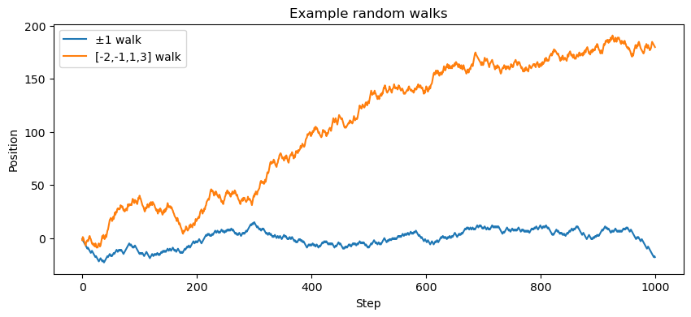

```python
import matplotlib.pyplot as plt
rng = np.random.default_rng(seed=45)
plt.figure(figsize=(10,4))

draws1 = rng.integers(0, 2, size=1000)
steps1 = np.where(draws1 == 0, 1, -1)
walk1 = steps1.cumsum()


plt.plot(walk1, label="±1 walk")

draws2 = rng.choice([-2,-1,1,3], size=1000)
walk2 = draws2.cumsum()

plt.plot(walk2, label="[-2,-1,1,3] walk")

plt.legend()
plt.title("Example random walks")
plt.xlabel("Step")
plt.ylabel("Position")
plt.show()
```

Your explanation:

- How does your code work?

I am going about the pure numpy way here, `walk1` is entirely grabbed from earlier implementations of the random walks. `walk2` is where things change as after some documentaiton reading I am using `numpy.random.Generator.choice()` which takes in an array argument at bare minimum. This will return a random sample of that array, which is then cumulatively summed with `draws2.cumsum()`

- In 2 cases above, which case tends to wander farther, and why?

I think the best way to describe each case is to look at the expected value and variance of each walk.

As a personal reminder, here are the formulas for expected value and variance; note that because we have the entire population, we use this formula for variance.

$$E[X] = x_1p_1 + x_2p_2 + ... + x_kp_k$$

$$Var(X) = E[X^2] - (E[X])^2$$

## Expected Values

Taking a look at expected values for `walk1` there is an equal probability of getting either a 1 or -1 so $p_1$ and $p_2$ are both $0.5$, $x_1 = $ and $x_2 = -1$

$$E[X] = (1 * 0.5) + ((-1) * 0.5)$$ $$E[X] = 0.5 + (-0.5) = 0$$

This tells us that we wouldn't expect our random walk to trend very far from $0$.

Looking the expected value of `walk2` our values for x are $[-2,-1,1,3]$ each with an equal probability of being selected of, $0.25$, therefore:

$$E[X] = ((-2) * 0.25) + ((-1) * 0.25) + (1 * 0.25) + (3 * 0.25)$$ $$E[X] = (-0.5) + (-0.25) + 0.25 + 0.75$$ $$E[X] = (-0.75) + 1 = 0.25$$

With an expected value of $0.25$ I would expect a positive trend to be apparent in `walk2`

## Variance

`walk1`: To find the variance of `walk1` we have to find $E[X^2]$ first:

$$E[X^2] = (0.5 * (1)^2) + (0.5 * (-1)^2)$$ $$E[X^2] = 0.5 + 0.5 = 1$$

Therefore:

$$ Var(X) = 1 - 0^2 = 1 $$

`walk2`: $$E[X^2] = (0.25 * (-2)^2) + (0.25 * (-1)^2) + (0.25 * 1^2) + (0.25 * 3^2) $$ $$E[X^2] = (0.25 * 4) + (0.25 * 1) + (0.25 * 1) + (0.25 * 9) $$ $$E[X^2] = 1 + 0.25 + 0.25 + 2.25 = 3.75 $$

Therefore:

$$ Var(X) = 3.75 - (0.25)^2 $$ $$ Var(X) = 3.75 - 0.0625 = 3.6875 $$

All of this to demonstrate that the variance of `walk2` is higher than `walk1` so we would expect more spread from `walk2`.

For a sanity check we can do all the above math in numpy:

```python
steps1 = np.array([1, -1])
prob1 = np.array([0.5, 0.5])
expected_value1 = np.sum(steps1 * prob1)
var1 = np.var(steps1)
print(f"Expected value Walk 1: {expected_value1}")
print(f"Variance of Walk 1: {var1}")

steps2 = np.array([-2, -1, 1, 3])
prob2 = np.array([0.25, 0.25, 0.25, 0.25])
expected_value2 = np.sum(steps2 * prob2)
var2 = np.var(steps2)
print(f"Expected value Walk 2: {expected_value2}")
print(f"Variance of Walk 2: {var2}")
```

```
Expected value Walk 1: 0.0
Variance of Walk 1: 1.0
Expected value Walk 2: 0.25
Variance of Walk 2: 3.6875
```